# Red wine quality - an Explorative Data Analysis

### Interaction sulphates X alcohol

> Sulphates and alcohol content seem to explain the difference in quality of red wines the best.

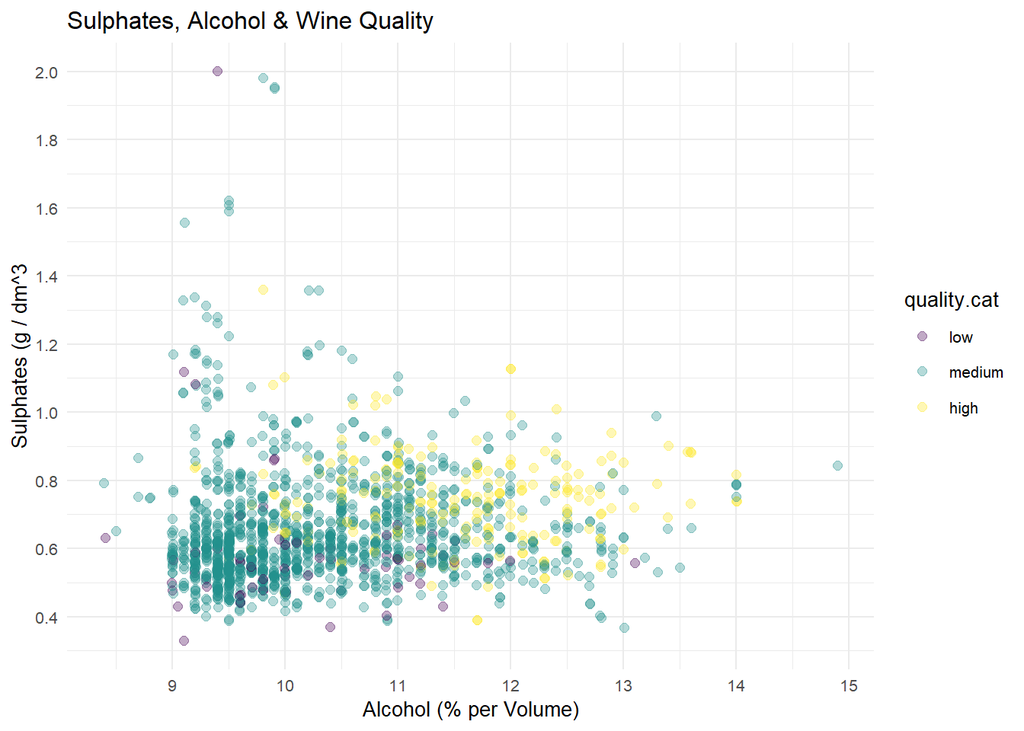

> High quality wines have a higher alcohol content and higher sulphates concentration than low quality wines and the majority of medium quality wines.

## Multivariate Analysis

### Talk about some of the relationships you observed in this part of the investigation. Were there features that strengthened each other in terms of looking at your feature(s) of interest?

> The plots of this section strengthened the observerations of the prior sections. High quality wines have a higher alcohol content, a higher sulphates concentration and a lower pH level compared to medium or low quality wines. I could not find the clear relationship between density and wine quality as the bivariate boxplot implied. Regarding the density, high and medium quality wines have a higher variance than low quality wines.

### Were there any interesting or surprising interactions between features?

> I couldn’t find any interactions.

## Final Plots and Summary

Now, I will present my three final plots.

### Plot One

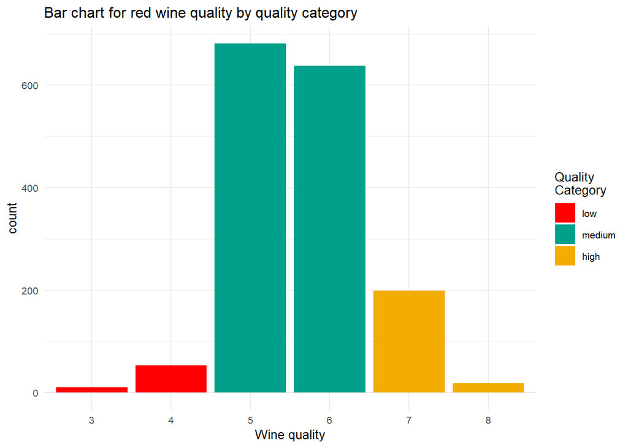

> This bar chart displays the count of red wine quality ratings while considering the three quality categories (low, medium and high). What this plot visualizes is that:  
> * First, the wine quality rating varies between 3 to 8 but theoretically it could vary between 1 to 10. Thus, no wine got a very bad or very good quality rating.  
> * Second, most wines in this dataset had a quality of 5 or 6. The fewest had a quality of 3 or 8.  
> * Third, the categorization of the quality into three categories works well for this data.